# HW5 - Problem 3 - Orange Juice classification

misken

March 26, 2018

# Problem 3 - Predicting orange juice purchases

The dataset is available as part of the ISLR package. You can see the documentation for that package or the following link describes the OJ dataset - https://rdrr.io/cran/ISLR/man/OJ.html.

**SUGGESTION**: See the material available in Downloads_StatModels2 from the session on classification models in R. In particular, the folder on logistic regression and the example in the folder intro_class_HR/ will be useful.

## Data prep

We’ll do a little data prep to set things up so that we are trying to predict whether or not the customer purchased Minute Maid (vs Citrus Hill.) Just run the following chunks to load the dataset, do some data prep and then partition the data into training and test sets.

```r
ojsales <- (ISLR::OJ)
```

Loading a few libraries

```r
library(dplyr)
```

```r
library(ggplot2)
library(useful)
library(coefplot)
library(caret)
library(lattice)
library(rpart)
library(rpart.plot)
library(RColorBrewer)
library(class)
library(randomForest)
library(reshape2)
```

Clean up the storeid related fields. Drop Store7 field.

```r
ojsalesdf <- ojsales[ojsales$StoreID != "7",]

# Omitting NA's in the dataframe
na.omit(ojsalesdf)
```

[output not shown]

[output cut: 2130 more lines]

```r
ojsalesdf$StoreID <- as.factor(ojsalesdf$StoreID)

# Create a new variable to act as the response variable.
ojsalesdf$MM <- as.factor(ifelse(ojsalesdf$Purchase=="MM",1,0))
```

Now we’ll just take a subset of the columns as there are a few that contain the same information. Remember, the new column `MM` is the one we are trying to predict.

```r
ojsalesdf_subset <- ojsalesdf[, c(19, 3:13, 15:17)]
```

Just run this chunk to create training and test datasets. This way we’ll all be working with the same datasets. Notice that the test set is 10% of the full dataset.

```r
set.seed(167)
sample_size <- ceiling(0.10 * nrow(ojsalesdf))
testrecs <- sample(nrow(ojsalesdf_subset),sample_size)
ojsalesdf_test <- ojsalesdf_subset[testrecs,]
ojsalesdf_train <- ojsalesdf_subset[-testrecs,]  # Negative in front of vector means "not in"
#rm(ojsalesdf_subset, ojsalesdf) # No sense keeping a copy of the entire dataset around
```

# EDA

Let’s check if we really got rid of the StoreID 7 from our dataframe. Yup, we did!

```r
head(ojsalesdf_train)
```

```
##    MM StoreID PriceCH PriceMM DiscCH DiscMM SpecialCH SpecialMM LoyalCH
## 2   0       1    1.75    1.99   0.00    0.3         0         1    0.60
## 3   0       1    1.86    2.09   0.17    0.0         0         0    0.68
## 4   1       1    1.69    1.69   0.00    0.0         0         0    0.40
## 17  1       1    1.75    1.99   0.00    0.3         0         1    0.50
## 18  1       2    1.86    2.18   0.00    0.0         0         1    0.40
## 19  1       2    1.86    2.18   0.00    0.0         0         0    0.32
##    SalePriceMM SalePriceCH PriceDiff PctDiscMM PctDiscCH ListPriceDiff
## 2         1.69        1.75     -0.06  0.150754  0.000000          0.24
## 3         2.09        1.69      0.40  0.000000  0.091398          0.23
## 4         1.69        1.69      0.00  0.000000  0.000000          0.00
## 17        1.69        1.75     -0.06  0.150754  0.000000          0.24
## 18        2.18        1.86      0.32  0.000000  0.000000          0.32
## 19        2.18        1.86      0.32  0.000000  0.000000          0.32
```

Let’s check our dataframe type now

```r
str(ojsalesdf_train)
```

```
## 'data.frame':    642 obs. of  15 variables:
##  $ MM           : Factor w/ 2 levels "0","1": 1 1 2 2 2 2 1 1 2 2 ...
##  $ StoreID      : Factor w/ 4 levels "1","2","3","4": 1 1 1 1 2 2 1 2 2 2 ...
##  $ PriceCH      : num  1.75 1.86 1.69 1.75 1.86 1.86 1.76 1.89 1.96 1.69 ...
##  $ PriceMM      : num  1.99 2.09 1.69 1.99 2.18 2.18 2.18 2.09 2.18 1.69 ...
##  $ DiscCH       : num  0 0.17 0 0 0 0 0 0 0 0 ...
##  $ DiscMM       : num  0.3 0 0 0.3 0 0 0 0 0.8 0 ...
##  $ SpecialCH    : num  0 0 0 0 0 0 0 0 0 1 ...
##  $ SpecialMM    : num  1 0 0 1 1 0 0 0 1 0 ...
##  $ LoyalCH      : num  0.6 0.68 0.4 0.5 0.4 0.32 0.68 0.5 0.68 0.68 ...
##  $ SalePriceMM  : num  1.69 2.09 1.69 1.69 2.18 2.18 2.18 2.09 1.38 1.69 ...
##  $ SalePriceCH  : num  1.75 1.69 1.69 1.75 1.86 1.86 1.76 1.89 1.96 1.69 ...
##  $ PriceDiff    : num  -0.06 0.4 0 -0.06 0.32 0.32 0.42 0.2 -0.58 0 ...
##  $ PctDiscMM    : num  0.151 0 0 0.151 0 ...
##  $ PctDiscCH    : num  0 0.0914 0 0 0 ...
##  $ ListPriceDiff: num  0.24 0.23 0 0.24 0.32 0.32 0.42 0.2 0.22 0 ...
```

Let’s take a look at the Summary of our dataframe

```r
summary(ojsalesdf_train)
```

```
##  MM      StoreID    PriceCH        PriceMM          DiscCH
##  0:339   1:140   Min.   :1.69   Min.   :1.690   Min.   :0.00000
##  1:303   2:201   1st Qu.:1.79   1st Qu.:1.990   1st Qu.:0.00000
##          3:179   Median :1.86   Median :2.090   Median :0.00000
##          4:122   Mean   :1.88   Mean   :2.085   Mean   :0.02447
##                  3rd Qu.:1.99   3rd Qu.:2.180   3rd Qu.:0.00000
##                  Max.   :2.09   Max.   :2.290   Max.   :0.30000
##      DiscMM         SpecialCH         SpecialMM         LoyalCH
##  Min.   :0.0000   Min.   :0.00000   Min.   :0.0000   Min.   :0.000011
##  1st Qu.:0.0000   1st Qu.:0.00000   1st Qu.:0.0000   1st Qu.:0.265203
##  Median :0.0000   Median :0.00000   Median :0.0000   Median :0.500000
##  Mean   :0.1118   Mean   :0.04673   Mean   :0.1869   Mean   :0.516675
##  3rd Qu.:0.0600   3rd Qu.:0.00000   3rd Qu.:0.0000   3rd Qu.:0.795200
##  Max.   :0.8000   Max.   :1.00000   Max.   :1.0000   Max.   :0.999947
##   SalePriceMM     SalePriceCH      PriceDiff         PctDiscMM
##  Min.   :1.190   Min.   :1.390   Min.   :-0.6700   Min.   :0.00000
##  1st Qu.:1.690   1st Qu.:1.768   1st Qu.: 0.0000   1st Qu.:0.00000
##  Median :2.090   Median :1.860   Median : 0.2000   Median :0.00000
##  Mean   :1.973   Mean   :1.856   Mean   : 0.1171   Mean   :0.05320
##  3rd Qu.:2.180   3rd Qu.:1.960   3rd Qu.: 0.3000   3rd Qu.:0.02752
##  Max.   :2.290   Max.   :2.090   Max.   : 0.4400   Max.   :0.40201
##    PctDiscCH       ListPriceDiff
##  Min.   :0.00000   Min.   :0.0000
##  1st Qu.:0.00000   1st Qu.:0.1000
##  Median :0.00000   Median :0.2400
##  Mean   :0.01261   Mean   :0.2045
##  3rd Qu.:0.00000   3rd Qu.:0.3000
##  Max.   :0.17752   Max.   :0.4400
```

Let’s try to fit our Model using Logistic Regression.

# Model 1: Logistic Regression

```r
MM_LogM1 <- glm(MM ~  .,
                    data=ojsalesdf_train, family=binomial(link="logit"))

summary(MM_LogM1)
```

```
##
## Call:
## glm(formula = MM ~ ., family = binomial(link = "logit"), data = ojsalesdf_train)
##
## Deviance Residuals:
##     Min       1Q   Median       3Q      Max
## -2.7294  -0.5640  -0.2025   0.5221   2.8531
##
## Coefficients: (4 not defined because of singularities)
##                 Estimate Std. Error z value Pr(>|z|)
## (Intercept)     9.510756   2.616793   3.635 0.000279 ***
## StoreID2        0.029150   0.325278   0.090 0.928593
## StoreID3        0.493294   0.387782   1.272 0.203341
## StoreID4        0.505444   0.441961   1.144 0.252773
## PriceCH         0.002177   1.885699   0.001 0.999079
## PriceMM        -3.271486   1.100692  -2.972 0.002957 **
## DiscCH         25.450008  24.666894   1.032 0.302190
## DiscMM         24.682932  13.138038   1.879 0.060280 .
## SpecialCH       0.276762   0.563645   0.491 0.623412
## SpecialMM       0.754838   0.390862   1.931 0.053457 .
## LoyalCH        -6.724594   0.543242 -12.379  < 2e-16 ***
## SalePriceMM           NA         NA      NA       NA
## SalePriceCH           NA         NA      NA       NA
## PriceDiff             NA         NA      NA       NA
## PctDiscMM     -47.916810  27.874553  -1.719 0.085611 .
## PctDiscCH     -50.455006  46.020153  -1.096 0.272918
## ListPriceDiff         NA         NA      NA       NA
## ---
## Signif. codes:  0 '***' 0.001 '**' 0.01 '*' 0.05 '.' 0.1 ' ' 1
##
## (Dispersion parameter for binomial family taken to be 1)
##
##     Null deviance: 887.98  on 641  degrees of freedom
## Residual deviance: 502.52  on 629  degrees of freedom
## AIC: 528.52
##
## Number of Fisher Scoring iterations: 5
```

Looks like our Model has fitted well, since the Residual deviance value is less than the value of Null deviance. But there are some of our co-efficients in the Model with NA values and for obvious reasons they does not look like to be contributing for our Model significance, let’s remove them from our Model and fit our Model and check if the Residual deviance and the Null deviance makes any difference.

```r
MM_LogM1 <- glm(MM ~  . - SalePriceMM - ListPriceDiff - SalePriceCH - PriceDiff,
                    data=ojsalesdf_train, family=binomial(link="logit"))

summary(MM_LogM1)
```

```
##
## Call:
## glm(formula = MM ~ . - SalePriceMM - ListPriceDiff - SalePriceCH -
##     PriceDiff, family = binomial(link = "logit"), data = ojsalesdf_train)
##
## Deviance Residuals:
##     Min       1Q   Median       3Q      Max
## -2.7294  -0.5640  -0.2025   0.5221   2.8531
##
## Coefficients:
##               Estimate Std. Error z value Pr(>|z|)
## (Intercept)   9.510756   2.616793   3.635 0.000279 ***
## StoreID2      0.029150   0.325278   0.090 0.928593
## StoreID3      0.493294   0.387782   1.272 0.203341
## StoreID4      0.505444   0.441961   1.144 0.252773
## PriceCH       0.002177   1.885699   0.001 0.999079
## PriceMM      -3.271486   1.100692  -2.972 0.002957 **
## DiscCH       25.450008  24.666894   1.032 0.302190
## DiscMM       24.682932  13.138038   1.879 0.060280 .
## SpecialCH     0.276762   0.563645   0.491 0.623412
## SpecialMM     0.754838   0.390862   1.931 0.053457 .
## LoyalCH      -6.724594   0.543242 -12.379  < 2e-16 ***
## PctDiscMM   -47.916810  27.874553  -1.719 0.085611 .
## PctDiscCH   -50.455006  46.020153  -1.096 0.272918
## ---
## Signif. codes:  0 '***' 0.001 '**' 0.01 '*' 0.05 '.' 0.1 ' ' 1
##
## (Dispersion parameter for binomial family taken to be 1)
##
##     Null deviance: 887.98  on 641  degrees of freedom
## Residual deviance: 502.52  on 629  degrees of freedom
## AIC: 528.52
##
## Number of Fisher Scoring iterations: 5
```

Okay, so after removal of the coefficient values from our Model with the NA values, the Model performance remains unchanged, as assumed.

Converting probabilities to 0 and 1 for predictions.

```r
yhat_LogM1 <- (MM_LogM1$fit > 0.5) * 1
```

Putting the fitted and the predicted values into a dataframe for ease of analysis

```r
MM_fit_predictions <- data.frame(MM_LogM1$y, yhat_LogM1)
names(MM_fit_predictions) <- c("yact","yhat_LogM1")
```

## Creating Confusion Matrix

```r
# Confusion Matrix
table(MM_fit_predictions$yact, MM_fit_predictions$yhat_LogM1)
```

```
##
##       0   1
##   0 289  50
##   1  60 243
```

```r
# Percentage of Precision and Recall
prop.table(table(MM_fit_predictions$yact, MM_fit_predictions$yhat_LogM1))
```

```
##
##              0          1
##   0 0.45015576 0.07788162
##   1 0.09345794 0.37850467
```

```r
cm_LogM1 <- confusionMatrix(MM_fit_predictions$yhat_LogM1, MM_fit_predictions$yact,
                            positive = "1")
cm_LogM1
```

```
## Confusion Matrix and Statistics
##
##           Reference
## Prediction   0   1
##          0 289  60
##          1  50 243
##
##                Accuracy : 0.8287
##                  95% CI : (0.7972, 0.857)
##     No Information Rate : 0.528
##     P-Value [Acc > NIR] : <2e-16
##
##                   Kappa : 0.6556
##  Mcnemar's Test P-Value : 0.3908
##
##             Sensitivity : 0.8020
##             Specificity : 0.8525
##          Pos Pred Value : 0.8294
##          Neg Pred Value : 0.8281
##              Prevalence : 0.4720
##          Detection Rate : 0.3785
##    Detection Prevalence : 0.4564
##       Balanced Accuracy : 0.8272
##
##        'Positive' Class : 1
##
```

Well, looks like our Logistic Regression data is well fit in between the probability of 0 and 1.

Visualizing the rate of purchase of MM vs CH. We got an almost ideal distribution scores with the scores of negative instances (0) to the left represented by the Orange Line and the distribution of positive instances (1) to the right represented by the dotted Green Line. This Orange solid line represents the distribution of the customer not buying MM or in other words the distribution of the customer buying CH and the dotted Green line represents the distributin of the customer buying MM or in other words the distribution of the customers not buying CH.

And this distribution is actually correct as we can see from the Confusion Matrix as well.

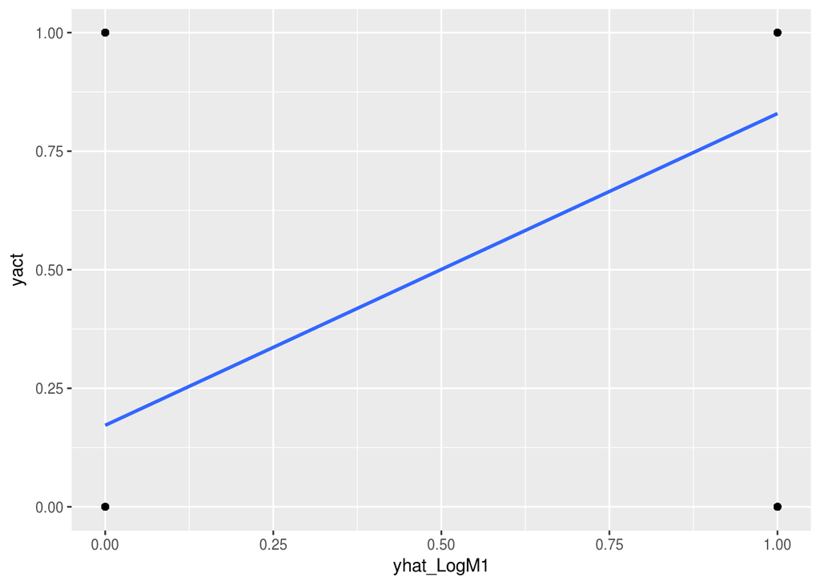

```r
ggplot(MM_fit_predictions, aes(x=yhat_LogM1, y=yact)) + geom_point() +
stat_smooth(method="glm", family="binomial", se=FALSE)
```

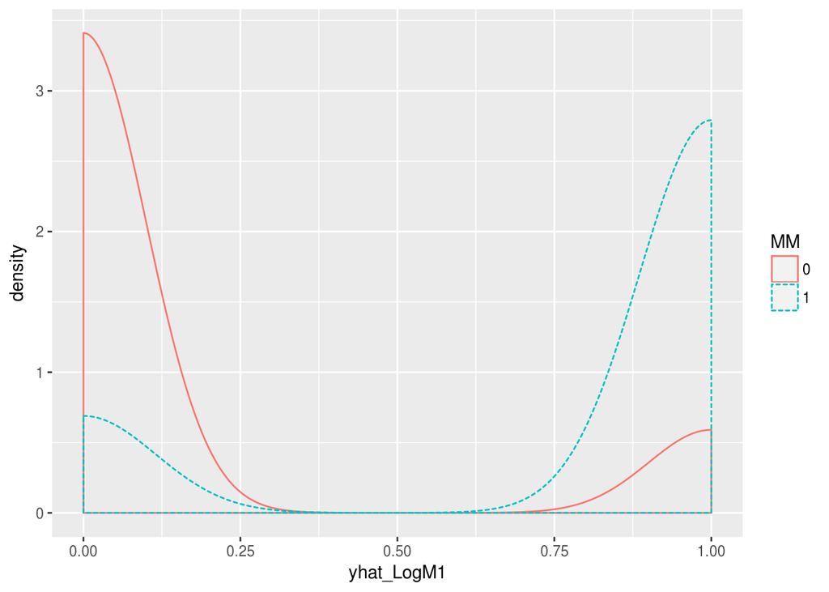

```r
# Double Density Plot
ggplot(ojsalesdf_train, aes(x=yhat_LogM1, color=MM, linetype=MM)) + geom_density()
```

## Predictions on Test Data for Model 1: Logistic Regression

```r
prob_LogM1 <- predict(MM_LogM1, newdata=ojsalesdf_test, type="response")
pred_LogM1 <- (prob_LogM1 > 0.5) * 1
head(pred_LogM1)
```

```
## 145 836 449 427 489 484
##   1   1   0   1   0   0
```

# Model 2: Simple Decision Tree

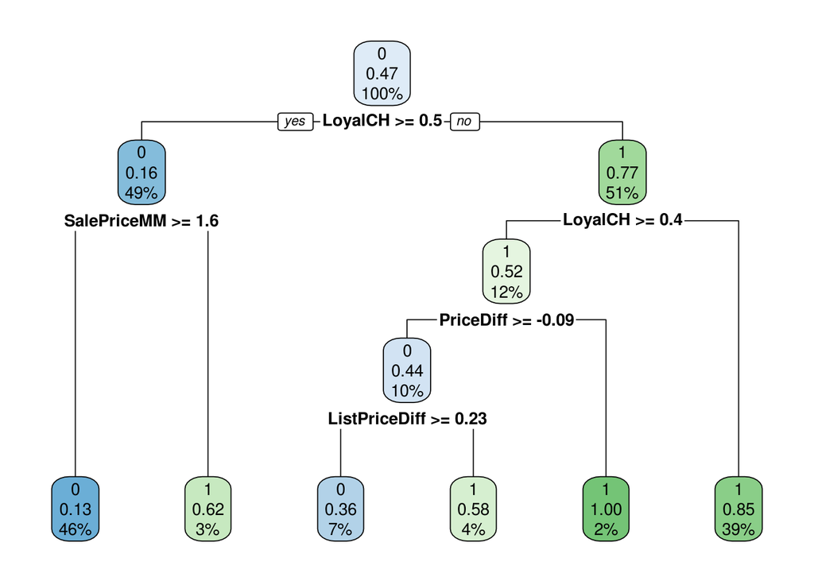

```r
MM_tree <- rpart(MM ~ ., data=ojsalesdf_train, method="class")

# Visualize the tree with rpart.plot
rpart.plot(MM_tree)
```

## Creating Confusion Matrix

```r
MM_fit_predictions$yhat_tree <- predict(MM_tree, type = "class")

# Confusion Matrix
table(MM_fit_predictions$yact, MM_fit_predictions$yhat_tree)
```

```
##
##       0   1
##   0 284  55
##   1  52 251
```

```r
# Percentage of Precision and Recall
prop.table(table(MM_fit_predictions$yact, MM_fit_predictions$yhat_tree))
```

```
##
##              0          1
##   0 0.44236760 0.08566978
##   1 0.08099688 0.39096573
```

```r
cm_tree <- confusionMatrix(MM_fit_predictions$yhat_tree, MM_fit_predictions$yact,
                            positive = "1")
cm_tree
```

```
## Confusion Matrix and Statistics
##
##           Reference
## Prediction   0   1
##          0 284  52
##          1  55 251
##
##                Accuracy : 0.8333
##                  95% CI : (0.8022, 0.8614)
##     No Information Rate : 0.528
##     P-Value [Acc > NIR] : <2e-16
##
##                   Kappa : 0.6658
##  Mcnemar's Test P-Value : 0.8467
##
##             Sensitivity : 0.8284
##             Specificity : 0.8378
##          Pos Pred Value : 0.8203
##          Neg Pred Value : 0.8452
##              Prevalence : 0.4720
##          Detection Rate : 0.3910
##    Detection Prevalence : 0.4766
##       Balanced Accuracy : 0.8331
##
##        'Positive' Class : 1
##
```

## Predictions on Test Data for Model 2: Simple Decision Tree

```r
pred_tree <- predict(MM_tree, newdata=ojsalesdf_test, type="class")
head(pred_tree)
```

```
## 145 836 449 427 489 484
##   1   0   0   1   0   0
## Levels: 0 1
```

You should build at least two classification models to try to predict MM. Our error metric will be overall accuracy.

Obviously, `ojsales_train` is your training dataset. After fitting each model, use the `caret::confusionMatrix` function to create a confusion matrix for each of the models based on the training data.

You should at least try the following two techniques: - logistic regression - a simple decision tree

**HACKER EXTRA:** Try additional techniques such as random forest, k-nearest neighbor or others.

# Model 3: Random Forest

```r
rand_forest <- randomForest(MM ~ ., data=ojsalesdf_train, method = "class")
rand_forest
```

```
##
## Call:
##  randomForest(formula = MM ~ ., data = ojsalesdf_train, method = "class")
##                Type of random forest: classification
##                      Number of trees: 500
## No. of variables tried at each split: 3
##
##         OOB estimate of  error rate: 19.94%
## Confusion matrix:
##     0   1 class.error
## 0 273  66   0.1946903
## 1  62 241   0.2046205
```

## Creating Confusion Matrix

```r
MM_fit_predictions$yhat_rf <- predict(rand_forest, type = "class")

# Confusion matrix
table(MM_fit_predictions$yact, MM_fit_predictions$yhat_rf)
```

```
##
##       0   1
##   0 273  66
##   1  62 241
```

```r
# Percentage of Precision and Recall
prop.table(table(MM_fit_predictions$yact, MM_fit_predictions$yhat_rf))
```

```
##
##              0          1
##   0 0.42523364 0.10280374
##   1 0.09657321 0.37538941
```

```r
cm_rf <- confusionMatrix(MM_fit_predictions$yhat_rf, MM_fit_predictions$yact,
                            positive = "1")
cm_rf
```

```
## Confusion Matrix and Statistics
##
##           Reference
## Prediction   0   1
##          0 273  62
##          1  66 241
##
##                Accuracy : 0.8006
##                  95% CI : (0.7676, 0.8309)
##     No Information Rate : 0.528
##     P-Value [Acc > NIR] : <2e-16
##
##                   Kappa : 0.6003
##  Mcnemar's Test P-Value : 0.7909
##
##             Sensitivity : 0.7954
##             Specificity : 0.8053
##          Pos Pred Value : 0.7850
##          Neg Pred Value : 0.8149
##              Prevalence : 0.4720
##          Detection Rate : 0.3754
##    Detection Prevalence : 0.4782
##       Balanced Accuracy : 0.8003
##
##        'Positive' Class : 1
##
```

## Predictions on Test Data for Model 3: Random Forest

```r
pred_rf <- predict(rand_forest, newdata=ojsalesdf_test, type="class")
head(pred_rf)
```

```
## 145 836 449 427 489 484
##   1   0   0   1   0   0
## Levels: 0 1
```

# Model 4: k-nearest Neighbor

```r
# Function to normalize data
normalize <- function(x) {
num <- x - min(x)
denom <- max(x) - min(x)
return (num/denom)
}
```

Checking the characteristics of our original dataframe

```r
str(ojsalesdf_subset)
```

```
## 'data.frame':    714 obs. of  15 variables:
##  $ MM           : Factor w/ 2 levels "0","1": 1 1 1 2 2 2 2 1 1 2 ...
##  $ StoreID      : Factor w/ 4 levels "1","2","3","4": 1 1 1 1 1 2 2 1 2 2 ...
##  $ PriceCH      : num  1.75 1.75 1.86 1.69 1.75 1.86 1.86 1.76 1.89 1.96 ...
##  $ PriceMM      : num  1.99 1.99 2.09 1.69 1.99 2.18 2.18 2.18 2.09 2.18 ...
##  $ DiscCH       : num  0 0 0.17 0 0 0 0 0 0 0 ...
##  $ DiscMM       : num  0 0.3 0 0 0.3 0 0 0 0 0.8 ...
##  $ SpecialCH    : num  0 0 0 0 0 0 0 0 0 0 ...
##  $ SpecialMM    : num  0 1 0 0 1 1 0 0 0 1 ...
##  $ LoyalCH      : num  0.5 0.6 0.68 0.4 0.5 0.4 0.32 0.68 0.5 0.68 ...
##  $ SalePriceMM  : num  1.99 1.69 2.09 1.69 1.69 2.18 2.18 2.18 2.09 1.38 ...
##  $ SalePriceCH  : num  1.75 1.75 1.69 1.69 1.75 1.86 1.86 1.76 1.89 1.96 ...
##  $ PriceDiff    : num  0.24 -0.06 0.4 0 -0.06 0.32 0.32 0.42 0.2 -0.58 ...
##  $ PctDiscMM    : num  0 0.151 0 0 0.151 ...
##  $ PctDiscCH    : num  0 0 0.0914 0 0 ...
##  $ ListPriceDiff: num  0.24 0.24 0.23 0 0.24 0.32 0.32 0.42 0.2 0.22 ...
```

Rescaling all of our dataframes for building prediction Models with k-nearest neighbor Classification. Since our total number of observations = 714. Taking approximate value of the square root of the number of total observations. That is Square Root of 714 = 26.7.

```r
# Scaling the Dataframes
num.vars_subset <- sapply(ojsalesdf_subset, is.numeric)
ojsalesdf_subset[num.vars_subset] <- lapply(ojsalesdf_subset[num.vars_subset], scale)

num.vars_train <- sapply(ojsalesdf_train, is.numeric)
ojsalesdf_train[num.vars_train] <- lapply(ojsalesdf_train[num.vars_train], scale)

num.vars_test <- sapply(ojsalesdf_test, is.numeric)
ojsalesdf_test[num.vars_test] <- lapply(ojsalesdf_test[num.vars_test], scale)

# Prediction with k = 27
pred_knn27 <- knn(ojsalesdf_train, ojsalesdf_test, ojsalesdf_train$MM, k=27, prob = TRUE)
head(pred_knn27)
```

```
## [1] 0 1 0 1 0 0
## Levels: 0 1
```

## Creating Confusion Matrix

[figure not shown]

```r
pcol1 <- as.character(as.numeric(ojsalesdf_train$MM))
pairs(ojsalesdf_test, pch = pcol1, col = c("red", "green3")
  [(ojsalesdf_train$MM != pred_knn27)+1])
```

Then use the `predict()` function to make classification predictions on the test dataset and use `caret::confusionMatrix` to create a confusion matrix for each of the models for the predictions.

## Summarizing

```r
pred_results <- as.data.frame(cbind(pred_LogM1,
                                    pred_tree, pred_rf, pred_knn27, ojsalesdf_test$MM))

names(pred_results) <- c("pred_LogM1", "pred_tree", "pred_rf", "pred_knn27", "test_MM")
head(pred_results)
```

```
##     pred_LogM1 pred_tree pred_rf pred_knn27 test_MM
## 145          1         2       2          1       1
## 836          1         1       1          2       2
## 449          0         1       1          1       2
## 427          1         2       2          2       1
## 489          0         1       1          1       1
## 484          0         1       1          1       1
```

Hmmm, looks like the values are the level numbers. Let’s just adjust to match our logistic regression predictions for the rest of our Models.

```r
pred_results$pred_tree <- pred_results$pred_tree - 1
pred_results$pred_rf <- pred_results$pred_rf - 1
pred_results$pred_knn27 <- pred_results$pred_knn27 - 1
pred_results$test_MM <- pred_results$test_MM - 1
head(pred_results)
```

```
##     pred_LogM1 pred_tree pred_rf pred_knn27 test_MM
## 145          1         1       1          0       0
## 836          1         0       0          1       1
## 449          0         0       0          0       1
## 427          1         1       1          1       0
## 489          0         0       0          0       0
## 484          0         0       0          0       0
```

Now let’s just create a confusion matrix for each model and the actual values from the ojsalesdf_test dataset and compare their performance.

```r
cm_predLogM1 <- confusionMatrix(pred_results$pred_LogM1,
                                 pred_results$test_MM,
                                 positive = "1")

cm_predtree <- confusionMatrix(pred_results$pred_tree,
                                pred_results$test_MM,
                                positive = "1")

cm_predrf <- confusionMatrix(pred_results$pred_rf,
                                pred_results$test_MM,
                                positive = "1")

cm_predknn27 <- confusionMatrix(pred_results$pred_knn27,
                                pred_results$test_MM,
                                positive = "1")
```

## Confusion Matrix for Predicted Model 1: Logistic Regression

```r
cm_predLogM1
```

```
## Confusion Matrix and Statistics
##
##           Reference
## Prediction  0  1
##          0 32  8
##          1  8 24
##
##                Accuracy : 0.7778
##                  95% CI : (0.6644, 0.8673)
##     No Information Rate : 0.5556
##     P-Value [Acc > NIR] : 7.299e-05
##
##                   Kappa : 0.55
##  Mcnemar's Test P-Value : 1
##
##             Sensitivity : 0.7500
##             Specificity : 0.8000
##          Pos Pred Value : 0.7500
##          Neg Pred Value : 0.8000
##              Prevalence : 0.4444
##          Detection Rate : 0.3333
##    Detection Prevalence : 0.4444
##       Balanced Accuracy : 0.7750
##
##        'Positive' Class : 1
##
```

## Confusion Matrix for Predicted Model 2: Simple Decision Tree

```r
cm_predtree
```

```
## Confusion Matrix and Statistics
##
##           Reference
## Prediction  0  1
##          0 31 10
##          1  9 22
##
##                Accuracy : 0.7361
##                  95% CI : (0.619, 0.833)
##     No Information Rate : 0.5556
##     P-Value [Acc > NIR] : 0.00122
##
##                   Kappa : 0.4639
##  Mcnemar's Test P-Value : 1.00000
##
##             Sensitivity : 0.6875
##             Specificity : 0.7750
##          Pos Pred Value : 0.7097
##          Neg Pred Value : 0.7561
##              Prevalence : 0.4444
##          Detection Rate : 0.3056
##    Detection Prevalence : 0.4306
##       Balanced Accuracy : 0.7312
##
##        'Positive' Class : 1
##
```

## Confusion Matrix for Predicted Model 3: Random Forest

```r
cm_predrf
```

```
## Confusion Matrix and Statistics
##
##           Reference
## Prediction  0  1
##          0 31 11
##          1  9 21
##
##                Accuracy : 0.7222
##                  95% CI : (0.6041, 0.8214)
##     No Information Rate : 0.5556
##     P-Value [Acc > NIR] : 0.002721
##
##                   Kappa : 0.434
##  Mcnemar's Test P-Value : 0.823063
##
##             Sensitivity : 0.6562
##             Specificity : 0.7750
##          Pos Pred Value : 0.7000
##          Neg Pred Value : 0.7381
##              Prevalence : 0.4444
##          Detection Rate : 0.2917
##    Detection Prevalence : 0.4167
##       Balanced Accuracy : 0.7156
##
##        'Positive' Class : 1
##
```

## Confusion Matrix for Predicted Model 4: k- Nearest Neighbor

```r
cm_predknn27
```

```
## Confusion Matrix and Statistics
##
##           Reference
## Prediction  0  1
##          0 34  6
##          1  6 26
##
##                Accuracy : 0.8333
##                  95% CI : (0.727, 0.9108)
##     No Information Rate : 0.5556
##     P-Value [Acc > NIR] : 5.786e-07
##
##                   Kappa : 0.6625
##  Mcnemar's Test P-Value : 1
##
##             Sensitivity : 0.8125
##             Specificity : 0.8500
##          Pos Pred Value : 0.8125
##          Neg Pred Value : 0.8500
##              Prevalence : 0.4444
##          Detection Rate : 0.3611
##    Detection Prevalence : 0.4444
##       Balanced Accuracy : 0.8313
##
##        'Positive' Class : 1
##
```

## Accuracy & Sensitivity for all the Fitted Models

```r
# Model 1: Logistic Regression
sprintf("Model 1 - Logistic Regression: Accuracy = %8.4f Sensitivity = %8.4f",
        cm_LogM1$overall["Accuracy"],
        cm_LogM1$byClass["Sensitivity"])
```

```
## [1] "Model 1 - Logistic Regression: Accuracy =   0.8287 Sensitivity =   0.8020"
```

```r
# Model 2: Simple Decision Tree
sprintf("Model 1 - Simple Decision Tree: Accuracy = %8.4f Sensitivity = %8.4f",
        cm_tree$overall["Accuracy"],
        cm_tree$byClass["Sensitivity"])
```

```
## [1] "Model 1 - Simple Decision Tree: Accuracy =   0.8333 Sensitivity =   0.8284"
```

```r
# Model 3: Random Forest
sprintf("Model 1 - Random Forest: Accuracy = %8.4f Sensitivity = %8.4f",
        cm_rf$overall["Accuracy"],
        cm_rf$byClass["Sensitivity"])
```

```
## [1] "Model 1 - Random Forest: Accuracy =   0.8006 Sensitivity =   0.7954"
```

## Accuracy & Sensitivity for all the Predicted Models

```r
# Model 1: Logistic Regression
sprintf("Model 1 - Logistic Regression: Accuracy = %8.4f Sensitivity = %8.4f",
        cm_predLogM1$overall["Accuracy"],
        cm_predLogM1$byClass["Sensitivity"])
```

```
## [1] "Model 1 - Logistic Regression: Accuracy =   0.7778 Sensitivity =   0.7500"
```

```r
# Model 2: Simple Decision Tree
sprintf("Model 1 - Simple Decision Tree: Accuracy = %8.4f Sensitivity = %8.4f",
        cm_predtree$overall["Accuracy"],
        cm_predtree$byClass["Sensitivity"])
```

```
## [1] "Model 1 - Simple Decision Tree: Accuracy =   0.7361 Sensitivity =   0.6875"
```

```r
# Model 3: Random Forest
sprintf("Model 1 - Random Forest: Accuracy = %8.4f Sensitivity = %8.4f",
        cm_predrf$overall["Accuracy"],
        cm_predrf$byClass["Sensitivity"])
```

```
## [1] "Model 1 - Random Forest: Accuracy =   0.7222 Sensitivity =   0.6562"
```

```r
# Model 4: k-Nearest Neighbor
sprintf("Model 1 - k-Nearest Neighbor: Accuracy = %8.4f Sensitivity = %8.4f",
        cm_predknn27$overall["Accuracy"],
        cm_predknn27$byClass["Sensitivity"])
```

```
## [1] "Model 1 - k-Nearest Neighbor: Accuracy =   0.8333 Sensitivity =   0.8125"
```

Summarize your results.